# Ordered Categories

Corrie Bartelheimer

7/28/2019

# Ordered Categorical Outcomes

```r
library(rethinking)
data(Trolley)
d <- Trolley
```

The data contains answers of 331 individuals for different stories, about how morally permissible the action in the story is. The answer is an integer from 1 to 7. The outcome is thus categorical and ordered.

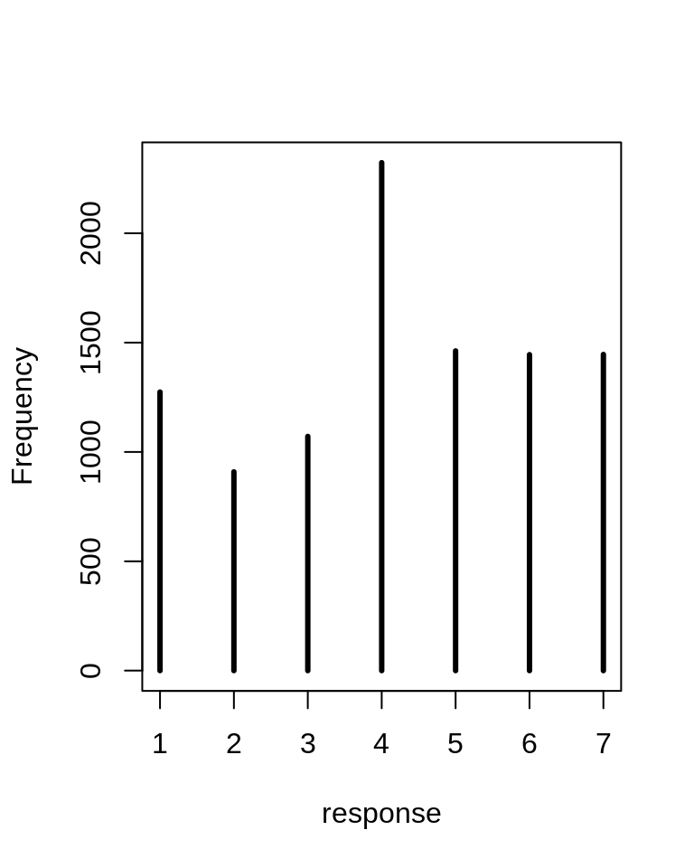

```r
simplehist( d$response, xlim=c(1,7), xlab="response")
```

## Describing an ordered distribution with intercepts

We want to redescribe this histogram on the log-cumulative-odds scale. We first compute the cumulative probabilities:

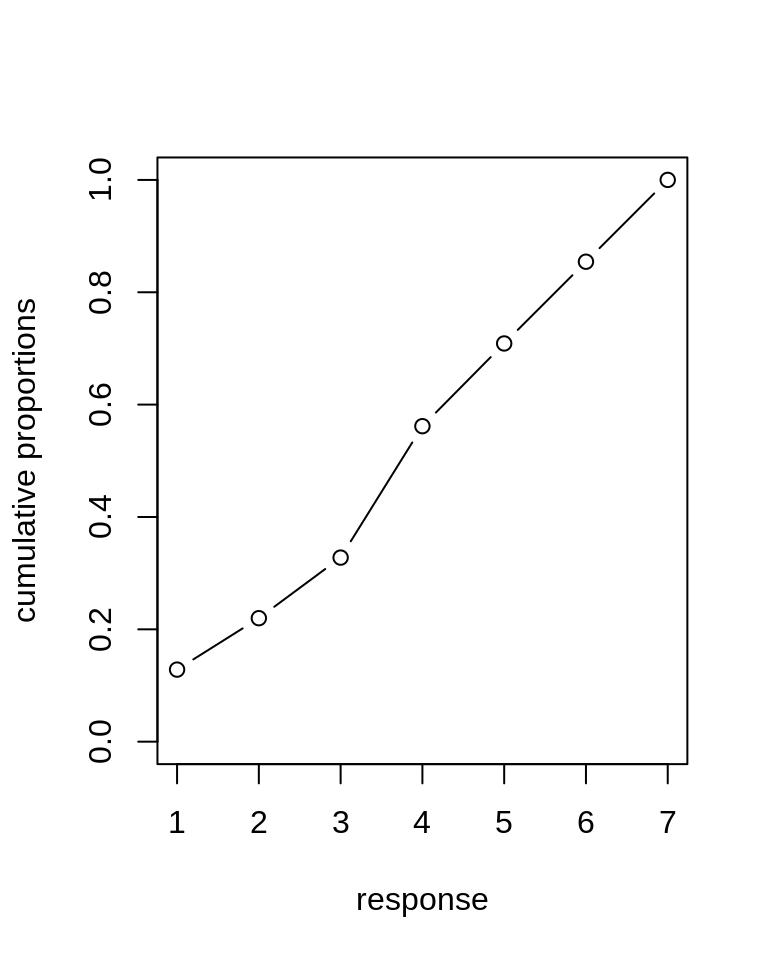

```r
pr_k <- table( d$response ) / nrow(d)

cum_pr_k <- cumsum( pr_k )

plot( 1:7, cum_pr_k, type="b", xlab="response",
      ylab="cumulative proportions", ylim=c(0, 1))
```

Next, to get the log-cumulative odds, we use the following link function to get an intercept parameter for each reponse:
$$\begin{align*}
\log \frac{Pr(y_i \leq k)}{1 - Pr(y_i \leq k)} = \alpha_k
\end{align*}$$
where $\alpha_k$ is the intercept parameter unique to each possible outcome value $k$.

```r
logit <- function(x) log(x/(1-x))
( lco <- logit( cum_pr_k ) )
```

```
         1          2          3          4          5          6
-1.9160912 -1.2666056 -0.7186340  0.2477857  0.8898637  1.7693809
         7
       Inf
```

The cumulative probability for the last response will always be 1, so its log-cumulative odds is always infinity and thus we only need 6 parameters.

From the log-cumulative odds, we can then get back again to our cumulative proportions by using the inverse of the link, and then obtain the likelihood for each (ordered) category by substraction.
$$p_k = Pr(y_i = k) = Pr(y_i \leq k) - Pr(y_i \leq k-1)$$
These likelihoods are the blue line segments in the following plot:

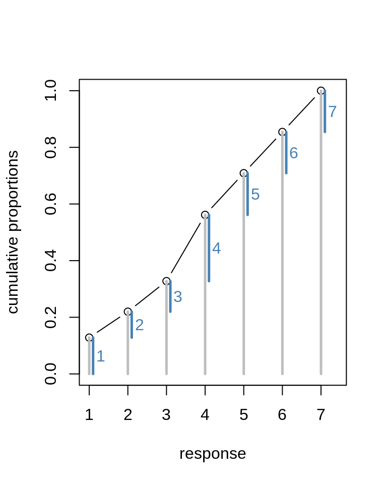

```r
plot( 1:7, cum_pr_k, type="b", xlab="response",
      ylab="cumulative proportions", ylim=c(0, 1), xlim=c(1, 7.4))
for (i in 1:7) {
  lines(c(i, i), c(0, cum_pr_k[i]) , lwd=2.5, col="grey")
  lines(c(i,i) + 0.1, c(cum_pr_k[i] - pr_k[i], cum_pr_k[i]),
        lwd=2.5, col="steelblue")
  text( i + 0.3, cum_pr_k[i] -  pr_k[i]/2, labels=i,
        col="steelblue")
}
```

Putting these together, we get this model:
$$\begin{align*}
R_i &\sim \text{Ordered-logit}(\phi_i, \kappa) &\text{[probability of data]}\\
\phi_i &= 0 &\text{[linear model]} \\
\kappa_k &\sim \text{Normal}(0, 1.5) &\text{[common prior for each intercept]}
\end{align*}$$

More verbose, this model is the same as
$$\begin{align*}
R_i &\sim \text{Categorical}(\boldsymbol p) &\text{[probability of data]}\\
p_i &= q_i &\text{[probabilities for each value }k] \\
p_k &= q_k - q_{k-1} \quad \text{ for } K > k > 1 & \\
p_K &= 1 - q_{k-1} & \\
\text{logit}(q_k) &= \kappa_k - \phi_i &\text{[cumulative logit link]} \\
\phi_i &= \text{terms of linear model} &\text{[linear model]} \\
\kappa_k &\sim \text{Normal}(0, 1.5) &\text{[common prior for each intercept]}
\end{align*}$$

In `ulam`:

```r
m12.5 <- ulam(
  alist(
    R ~ dordlogit( 0, cutpoints ),
    cutpoints ~ dnorm( 0, 1.5 )
  ),
  data=list( R = d$response ), chains=4, cores=3, refresh=0
)
```

or in quap, where we need to specify `start` values. The exact values aren’t important, but their ordering is:

```r
m12.5q <- quap(
  alist(
    response ~ dordlogit( 0, c(a1, a2, a3, a4, a5, a6)),
    c(a1,a2,a3,a4,a5,a6) ~ dnorm(0, 1.5)
  ), data=d,
  start=list(a1=-2, a2=-1, a3=0, a4=1, a5=2, a6=2.5)
)
```

The posterior distribution:

```r
precis( m12.5 , depth=2)
```

```
                   mean         sd       5.5%      94.5%    n_eff
cutpoints[1] -1.9174930 0.02969906 -1.9656343 -1.8711481 1651.385
cutpoints[2] -1.2668939 0.02399642 -1.3059431 -1.2293149 1957.125
cutpoints[3] -0.7181040 0.02108260 -0.7514681 -0.6850762 2248.739
cutpoints[4]  0.2479999 0.02021783  0.2151932  0.2795855 2508.361
cutpoints[5]  0.8907130 0.02224467  0.8550156  0.9247436 2589.319
cutpoints[6]  1.7698943 0.02759235  1.7256806  1.8144217 2337.179
                  Rhat
cutpoints[1] 0.9991045
cutpoints[2] 0.9983999
cutpoints[3] 0.9989382
cutpoints[4] 1.0008451
cutpoints[5] 0.9993758
cutpoints[6] 0.9995117
```

Note that these values are on the log-cumulative-odds scale. We transform them to the cumulative probabilities by using the inverse logit:

```r
inv_logit( coef(m12.5))
```

```
cutpoints[1] cutpoints[2] cutpoints[3] cutpoints[4] cutpoints[5]
   0.1281414    0.2197894    0.3278106    0.5616842    0.7090373
cutpoints[6]
   0.8544445
```

Compare this with the cumulative probabilities we computed earlier:

```r
cum_pr_k
```

```
        1         2         3         4         5         6         7
0.1282981 0.2198389 0.3276939 0.5616314 0.7088620 0.8543807 1.0000000
```

Okay great, we now have a Bayesian representation of the histogram from before. Lots of caclucation for rather little. But we can now include predictor variables in our model.

## Adding predictor variables

To include predictor variables, we add a linear model $\phi_i=\beta x_i$. Then each cumulative logit becomes:
$$\begin{align*}
\text{log}\frac{Pr(y_i \leq k)}{1 - Pr(y_i \leq k)} &= \alpha_k - \phi_i \\
\phi_i &= \beta x_i
\end{align*}$$
Why is the linear model $\phi$ subtracted from each intercept? Because if we decrease the log-cumulative-odds of every outcome value $k$ below the maximum, this necessarily shifts probability mass upwards towards higher outcome values. For example, suppose we take the posterior means from `m12.5` and subtract 0.5 from each:

```r
( pk <- dordlogit( 1:7, 0, coef(m12.5) ) )
```

```
[1] 0.12814139 0.09164803 0.10802122 0.23387352 0.14735313 0.14540724
[7] 0.14555548
```

These probabilities imply an average outcome value of:

```r
sum( pk * (1:7) )
```

```
[1] 4.199093
```

And now subtracting 0.5 from each:

```r
( pk <- dordlogit( 1:7, 0, coef(m12.5) - 0.5 ) )
```

```
[1] 0.08184846 0.06408057 0.08234127 0.20906099 0.15912305 0.18427032
[7] 0.21927535
```

Now values on the left have decreased while values on the right have increased. The expected value is now:

```r
sum( pk * (1:7) )
```

```
[1] 4.729442
```

That’s why we subtract $\phi$, the linear model, from each intercept. This way, a positive $\beta$ value indicates that an increase in the predictor variable $x$ results in an increase in the average response.

Going back to the trolley data, we will use `action`, `intention`, and `contact` as predictor variables. Since the influence of intention may depend upon the simultaneous presence of action or contact, we include an interaction. This gives us the following log-cumulative-odds:
$$\begin{align*}
\text{log}\frac{Pr(y_i \leq k)}{1 - Pr(y_i \leq k)} &= \alpha_k - \phi_i \\
\phi_i &= \beta_A A_i + \beta_C C_i + \text{B}_{I,i}I_i \\
\text {B}_{I,i} &= \beta_I + \beta_{IA}A_i + \beta_{IC}C_i
\end{align*}$$

For the interaction, we use an accessory linear model, $\text{B}_I$. This helps to make the notation clearer.

```r
dat <- list(
  R = d$response,
  A = d$action,
  I = d$intention,
  C = d$contact
)

m12.6 <- ulam(
  alist(
    R ~ dordlogit( phi, cutpoints ),
    phi <- bA*A + bC*C + BI*I,
    BI <- bI + bIA*A + bIC*C,
    c(bA, bI, bC, bIA, bIC) ~ dnorm(0, 0.5),
    cutpoints ~ dnorm( 0, 1.5)
  ), data=dat, chains=4, cores=4, refresh=0 )
```

```r
precis(m12.6)
```

```
          mean         sd       5.5%      94.5%     n_eff     Rhat
bIC -1.2390462 0.09606450 -1.3928385 -1.0865432 1252.0572 1.000325
bIA -0.4402065 0.07995726 -0.5694259 -0.3149000 1076.3962 1.000651
bC  -0.3392675 0.06866657 -0.4522828 -0.2339710 1237.9837 1.000931
bI  -0.2877942 0.05803153 -0.3823037 -0.1992507  937.6053 1.002585
bA  -0.4678606 0.05456051 -0.5540639 -0.3840088  958.7153 1.001618
```

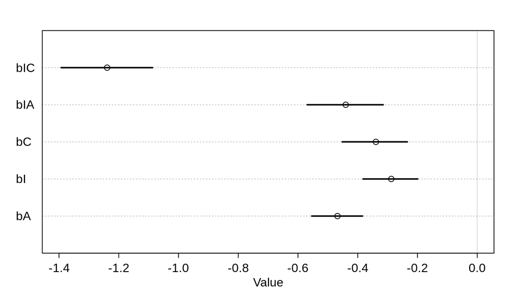

```r
plot( precis(m12.6), xlim=c(-1.4, 0))
```

The combination of contact and intention is the worst. Interestingly, neither contanct nor intention by itself have a large impact on ratings.

Visualizing log-cumulative-odds models is not quite straight-forward. That is because each prediction is actually a vector of probabilities, one probability for each possible response value.

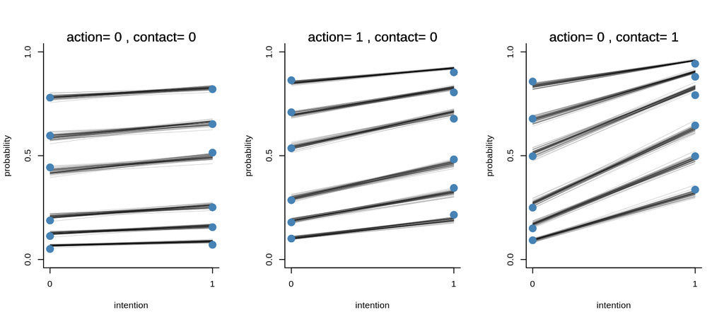

```r
post <- extract.samples(m12.6)

par(mfrow=c(1,3))
modi <- c("00", "10", "01")
for (modus in modi) {
  plot (NULL, type="n", xlab="intention", ylab="probability",
      xlim=c(0,1), ylim=c(0,1), xaxp=c(0,1,1), yaxp=c(0,1,2), bty="l" )

  kA <- as.numeric( substring(modus, 1,1) )
  kC <- as.numeric( substring(modus, 2,2) )

  kI <- 0:1
  pdat <- data.frame(A=kA, C=kC, I=kI)
  phi <- link( m12.6, data=pdat )$phi

  for (k in 1:3){

    for (s in 1:50) {
      pk <- pordlogit( 1:6, phi[s, ], post$cutpoints[s,])
      for (i in 1:6) {
        lines( kI, pk[, i], col=col.alpha("black", 0.1), lwd=0.4)
      }

    }
    mtext(paste("action=",kA, ", contact=", kC ))

    temp <- d %>%
      filter(action == kA & contact == kC) %>%
      select(response, intention) %>%
      group_by(response, intention) %>%
      summarize(n=n()) %>%
      group_by(intention) %>%
      arrange(response) %>%
      mutate(prop = n / sum(n), cumprop = cumsum(prop)) %>%
      filter(response != 7)
    points(temp$intention, temp$cumprop, col="steelblue", pch=19, cex=1.7)
  }
}
```

This plot shows how the distribution of predicted responses varies by `intention`. We can see that if `contact = 1` then intention has the highest impact so that this story combination is deemed by people the least morally permissible (most people have given low-valued responses).

We can also visualize the histogram of outcomes:

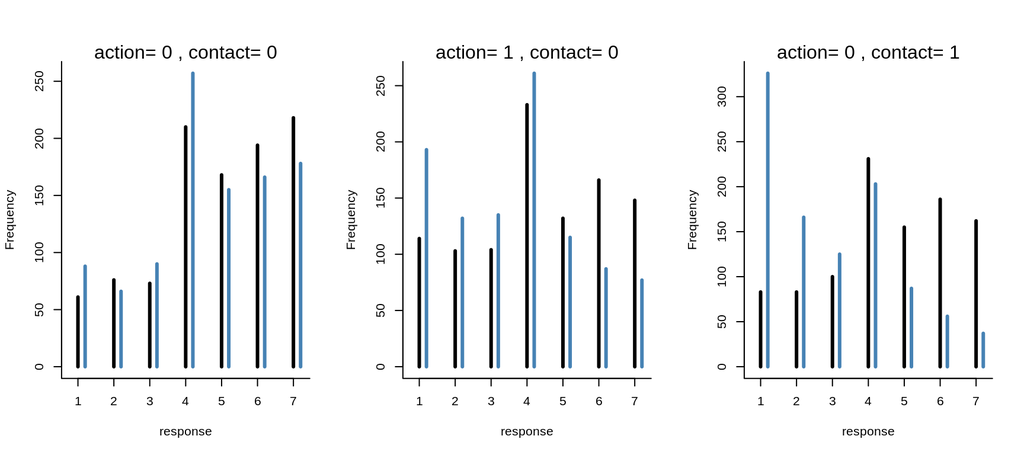

```r
par(mfrow=c(1,3))
for (modus in modi) {
  kA <- as.numeric( substring(modus, 1,1) )
  kC <- as.numeric( substring(modus, 2,2) )

  kI <- 0:1
  kI <- 0:1
  pdat <- data.frame(A=kA, C=kC, I=kI)
  s <- sim( m12.6, data=pdat)
  simplehist( s, xlab="response", col=c("black", "steelblue"), bty="l")
  mtext(paste("action=",kA, ", contact=", kC ))
}
```

The blue segments are the frequences when `intention` is 1. In this visualization it is easy to see that some answers are more salient than others: the middle response 4 is much more frequent. This is one reason why it is better to treat these kind of responses as ordered categorical outcomes instead of just as an ordinary metric variable.

# Ordered Categorical Predictors

Just as we can have ordered categorical outcomes, we can also have ordered predictor variables. In this data set for example, there is the variable of completed education:

```r
levels(d$edu)
```

```
[1] "Bachelor's Degree"    "Elementary School"    "Graduate Degree"
[4] "High School Graduate" "Master's Degree"      "Middle School"
[7] "Some College"         "Some High School"
```

The right order is as follows:

```r
edu_levels <- c(2, 6, 8, 4, 7, 1, 5, 3)
d$edu_new <- edu_levels[ d$edu]
levels(d$edu)[edu_levels]
```

```
[1] "Elementary School"    "Middle School"        "Some High School"
[4] "High School Graduate" "Some College"         "Bachelor's Degree"
[7] "Master's Degree"      "Graduate Degree"
```

The idea is, that for such a categorical predictor, each step up in value comes with its own incremental effect on the outcome. So completing middle school can have a different impact than completing your bachelor. We will absorb the first level into the intercept, which means with 8 education levels we will need 7 parameters. We get a linear model as follows:
$$\phi_i = \beta_E \sum_{j=0}^{E_i -1} \delta_j + \text{other stuff}$$
where the parameter $\delta_j$ is the effect of completing the $j$th level of education and $E_i$ the completed education level of individual $i$. The parameters $\delta_j$ are fractions so that $\sum_{j=0}^{7}\delta_j = 1$. This means that $\beta_E$ is the maximum effect of education. This parameterization also helps with setting priors. If for example the prior expectation is that all of the levels have the same incremental effect, then we want all the $\delta_j$’s to have the same prior. We can set a separate prior for $\beta_E$.

So now our full model:
$$\begin{align*}
R_i &\sim \text{Ordered-logit}(\phi_i, \kappa) \\
\phi_i &= \beta_E \sum_{j=0}^{E_i -1} \delta_j + \beta_A A_i + \beta_I I_i + \beta_C C_i \\
\kappa_k &\sim \text{Normal}(0, 1.5) \\
\beta_A, \beta_I, \beta_C, \beta_E &\sim \text{Normal}(0, 1) \\
\delta &\sim \text{Dirichlet}(\alpha)
\end{align*}$$

The prior for $\delta$ is a Dirichlet distribution which is the multivariate extension of the beta distribution. The Dirichlet distribution is parametrized by a vector $\alpha$ of pseudo-counts for each possibility. We’ll use a rather weak prior with each value inside $\alpha$ being 2. Let’s simulate from this prior:

```r
library(gtools)
set.seed(1805)
delta <- rdirichlet( 10, alpha = rep(2,7))
str(delta)
```

```
 num [1:10, 1:7] 0.1053 0.2504 0.1917 0.1241 0.0877 ...
```

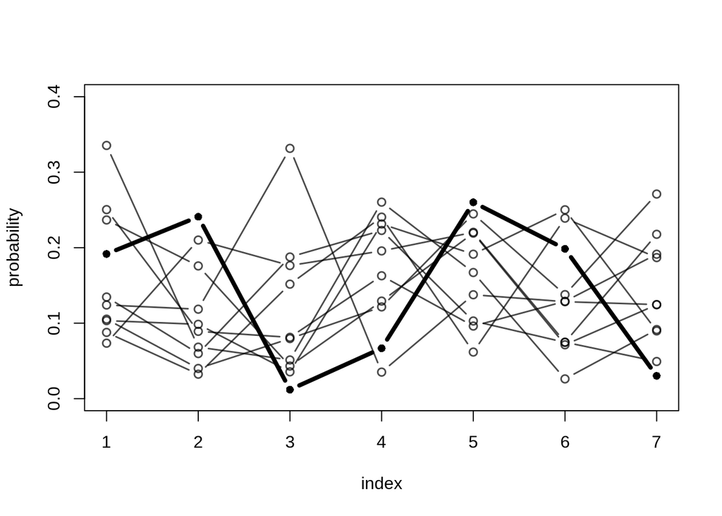

```r
h <- 3
plot(NULL, xlim=c(1,7), ylim=c(0,0.4), xlab="index", ylab="probability")
for (i in 1:nrow(delta) ) {
  lines( 1:7, delta[i,], type="b",
         pch=ifelse(i==h, 16, 1),
         lwd=ifelse(i==h, 4, 1.5),
         col=ifelse(i==h, "black", col.alpha("black", 0.7)))
}
```

The highlighted vector isn’t special but simply shows how much variation can exist in a single vector.

Now, let’s code the model:

```r
dat <- list(
  R = d$response,
  action = d$action,
  intention = d$intention,
  contact = d$contact,
  E = as.integer(d$edu_new ),   # edu_new as an index
  alpha = rep(2, 7)             # delta prior
)

m12.7 <- ulam(
  alist(
    R ~ ordered_logistic( phi, kappa ),
    phi <- bE*sum( delta_j[1:E] ) + bA*action + bI*intention + bC*contact,
    kappa ~ normal( 0, 1.5 ),
    c(bA, bI, bC, bE) ~ normal( 0, 1 ),
    vector[8]: delta_j <<- append_row( 0, delta ),
    simplex[7]: delta ~ dirichlet(alpha)
  ), data=dat, chains=3, cores=3, refresh=0
)
```

```r
precis(m12.7, depth=2, omit="kappa")
```

```
                mean         sd        5.5%      94.5%     n_eff      Rhat
bE       -0.23955220 0.05535948 -0.33043835 -0.1534262 1171.0239 0.9994925
bC       -0.95998881 0.05032232 -1.03789393 -0.8809859 1087.2500 1.0008318
bI       -0.71644278 0.03641935 -0.77357484 -0.6570472  988.9732 1.0009744
bA       -0.70651988 0.04059218 -0.77230543 -0.6437900 1128.8248 1.0015964
delta[1]  0.11731302 0.07379248  0.02595775  0.2549488 1486.7975 1.0000985
delta[2]  0.13462257 0.08471558  0.02842455  0.2961494 1756.5228 1.0000438
delta[3]  0.21216133 0.11290494  0.05084380  0.4098635 1498.7554 1.0013122
delta[4]  0.28961816 0.12692586  0.08951276  0.4967899 1266.2719 1.0034171
delta[5]  0.06283843 0.04455529  0.01231496  0.1461090 2144.4954 0.9996112
delta[6]  0.07247541 0.04785676  0.01455910  0.1607375 1591.2526 0.9999188
delta[7]  0.11097109 0.06910899  0.02506494  0.2397922 1618.1932 0.9987749
```

The overall associaton of education is negative, more educated individuals disapproved more of everything.

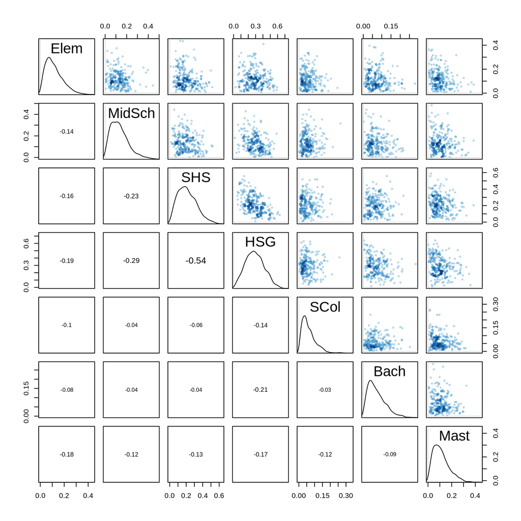

```r
delta_labels <- c("Elem", "MidSch", "SHS", "HSG", "SCol", "Bach", "Mast", "Grad")
pairs( m12.7, pars="delta", labels=delta_labels )
```

All but one level of education (Some Colege, SCol) produce some modest increment on average.

Let’s compare this posterior with one we would get from a more conventional model where education is entered as an ordinary continuous variable.

```r
dat$edu_norm <- normalize( d$edu_new )
m12.8 <- ulam(
  alist(
    R ~ ordered_logistic( mu, cutpoints ),
    mu <- bE*edu_norm + bA*action + bI*intention + bC*contact,
    c(bA, bI, bC, bE) ~ normal( 0, 1) ,
    cutpoints ~ normal( 0, 1.5)
  ), data=dat, chains=3, cores=3, refresh=0
)
precis( m12.8 )
```

```
         mean         sd       5.5%      94.5%     n_eff      Rhat
bE -0.2083591 0.05635846 -0.2998516 -0.1193611 1317.5533 0.9997423
bC -0.9567278 0.04918778 -1.0334700 -0.8764380 1056.4169 0.9997194
bI -0.7165121 0.03741372 -0.7775299 -0.6545371 1125.1807 1.0017831
bA -0.7033555 0.03944865 -0.7643453 -0.6398843  972.3608 0.9980792
```

This model finds a slightly weaker association between education and the rating response. This is possibly because the effect isn’t actually linear; different levels have different incremental associations.